# Using Requests and JSON in Python

## Why do we need serialization?

We need Serialization for the following reasons:

- **`Communication`**: Serialization involves the procedure of object serialization and transmission. This enables multiple computer systems to design, share and execute objects simultaneously.
- **`Caching`**: The time consumed in building an object is more compared to the time required for de-serializing it. Serialization minimizes time consumption by caching the giant objects.
- **`Deep Copy`**: Cloning process is made simple by using Serialization. An exact replica of an object is obtained by serializing the object to a byte array, and then de-serializing it.
- **`Portability`**: The major advantage of Serialization is that it works across different architectures or Operating Systems.
- **`Persistence`**: The State of any object can be directly stored by applying Serialization on to it and stored in a database so that it can be retrieved later.

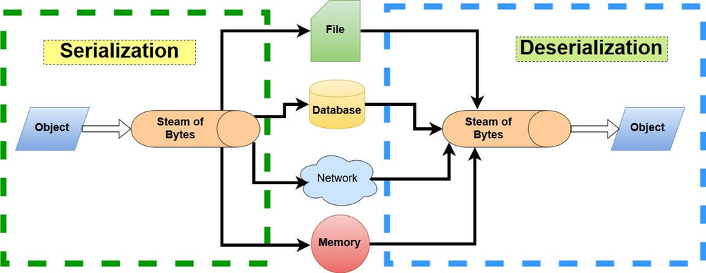

Image Source: Phonlawat Khunphet

## JSON

- JSON (JavaScript Object Notation) is a lightweight data-interchange format.
- It is easy for humans to read and write and for machines to parse and generate.
- JSON data is a collection of key/value pairs; in Python, it is realized by a dictionary.
- It stores data in the name/value pairs. It is treated as an object, record, dictionary, hash table, keyed list.

## JSON OBJECTS

JSON mainly supports 6 types of data type In JavaScript:  
`String`  
`Number`  
`Boolean`  
`Null`  
`Object`  
`Array`

## FUNCTIONS OF JSON

The main functions of `JSON` are:

- `dump()`: encoded string writing on file.
- `load()`: Decode while JSON file read.
- `dumps()`: encoding to JSON objects
- `loads()`: Decode the JSON string.

## EXAMPLE

```python
import json
```

```python
resp = req.request(method='GET', url="http://ip-api.com/json/")
```

```python
json_page = json.loads(resp.text)
pprint.pprint(json_page)
```

```
{'as': 'AS132923 Vihaan Telecommunication Pvt. Ltd.',
 'city': 'Ahmedabad',
 'country': 'India',
 'countryCode': 'IN',
 'isp': 'Vihaan Telecommunication Pvt. Ltd.',
 'lat': 23.0276,
 'lon': 72.5871,
 'org': 'Vihaan',
 'query': '103.240.32.202',
 'region': 'GJ',
 'regionName': 'Gujarat',
 'status': 'success',
 'timezone': 'Asia/Kolkata',
 'zip': '380009'}
```

## Serialization

- The encoding of JSON data is called `Serialization`. Serialization is a technique where data transforms in the series of bytes and transmitted across the network.`
- The `Deserialization` is the reverse process of decoding the data that is converted into the JSON format.

We use the `dump()` that takes two arguments: * The data object to be serialized. * The file object to which it will be written (Byte format).

```python
file_name = "Sample.json"
with open(file_name, "w") as fid:
     json.dump(json_page, fid)
```

## JSON LOAD

```python
with open(file_name, "r") as fid:
     json_obj = json.load(fid)

print(json_obj)
```

[output not shown]

## PRETTY PRINT

```python
for key in json_obj:
    print("{:>12}: {}".format(key, json_obj[key]))
```

```
      status: success
     country: India
 countryCode: IN
      region: GJ
  regionName: Gujarat
        city: Ahmedabad
         zip: 380009
         lat: 23.0276
         lon: 72.5871
    timezone: Asia/Kolkata
         isp: Vihaan Telecommunication Pvt. Ltd.
         org: Vihaan
          as: AS132923 Vihaan Telecommunication Pvt. Ltd.
       query: 103.240.32.202
```

[figure not shown]

Manish Patel